# Reproducible Research Peer graded assignment 1

Menno Oerlemans

6 september 2017

## Loading and preprocessing the data

The data is loaded from the URL given.

The class was analysed after loading the file from the downloaded zip file and the only collumn which had to be adjusted was the date collumn.

```
## [1] "2017-09-11"
```

## What is mean total number of steps taken per day?

This step exists of two parts:  
- Summerizing the steps perday  
- plotting the steps in a histogram

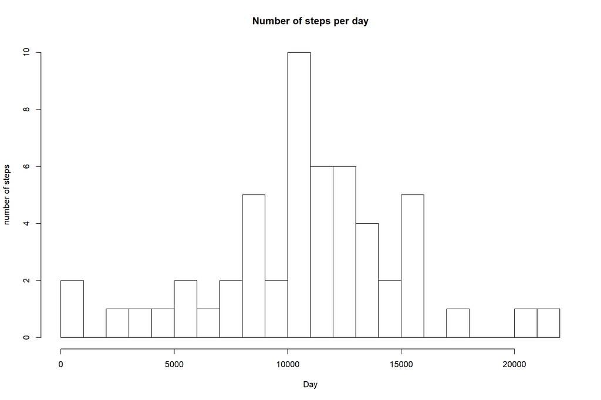

## What is the average daily activity pattern?

Within this part the bullets 3 to 5 are answered.

The first question is the mean and the medium. Here the NA’s are excluded.

```
## Mean   : 10766.19
```

```
##   Median : 10765
```

The next question is the plot with the time series and the steps at that particular time of day. You can see that the top is between 800 and 900.

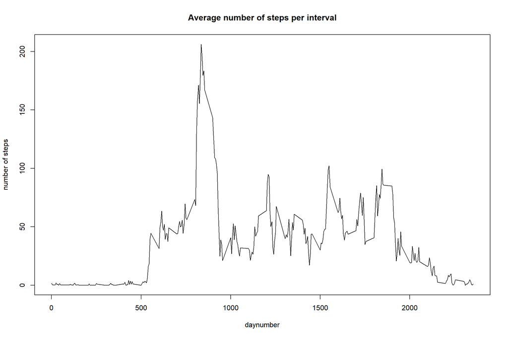

The next question is the interval with the highest number of steps. This is 835.

```
## Source: local data frame [1 x 2]
##
##   interval total_steps
##      (int)       (dbl)
## 1      835    206.1698
```

## Imputing missing values

Within this question two bullets are answered:  
- the impute strategy  
- plotting the results

### Impute strategy

During the day the mean of the steps during a certain intervals varies a lot.This means that de daily average is not a good impute strategy. The other available variable is the interval. The impute strategy choosen was the mean during the interval in the available observations. There are no intervals with no observation at all.

The plotting code was identical as the code for Question 2.

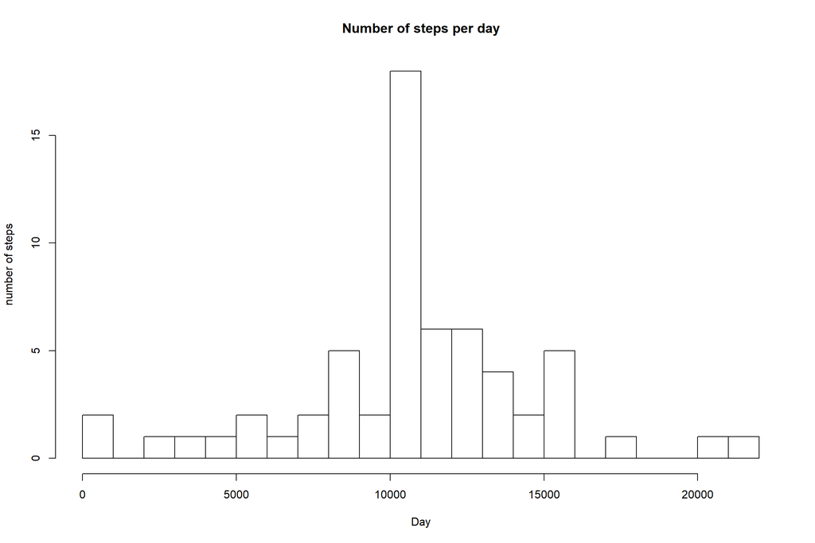

## Are there differences in activity patterns between weekdays and weekends?

To answer the last question three steps were coded:  
1. Splitting the data in weekday’s (day 2 to 6) and weekends (day 1 and 7)  
2. calculating the mean per interval (weekend and weekdays)  
3. printing the two plots (one for weekend en one for weekdays) where the average number of steps per interval are shown.

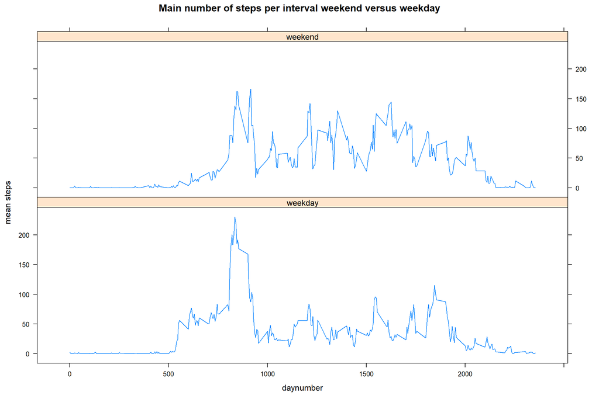